```r
#Q1
library(datasets)
str(mtcars)
```

```
## 'data.frame':    32 obs. of  11 variables:
##  $ mpg : num  21 21 22.8 21.4 18.7 18.1 14.3 24.4 22.8 19.2 ...
##  $ cyl : num  6 6 4 6 8 6 8 4 4 6 ...
##  $ disp: num  160 160 108 258 360 ...
##  $ hp  : num  110 110 93 110 175 105 245 62 95 123 ...
##  $ drat: num  3.9 3.9 3.85 3.08 3.15 2.76 3.21 3.69 3.92 3.92 ...
##  $ wt  : num  2.62 2.88 2.32 3.21 3.44 ...
##  $ qsec: num  16.5 17 18.6 19.4 17 ...
##  $ vs  : num  0 0 1 1 0 1 0 1 1 1 ...
##  $ am  : num  1 1 1 0 0 0 0 0 0 0 ...
##  $ gear: num  4 4 4 3 3 3 3 4 4 4 ...
##  $ carb: num  4 4 1 1 2 1 4 2 2 4 ...
```

```r
summary(mtcars$mpg)
```

```
##    Min. 1st Qu.  Median    Mean 3rd Qu.    Max.
##    10.4    15.4    19.2    20.1    22.8    33.9
```

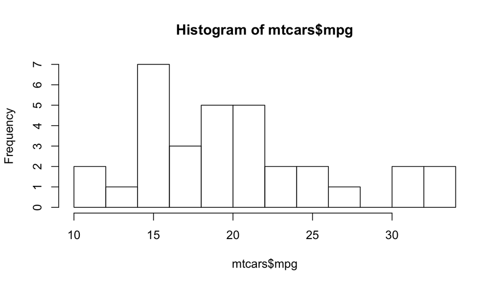

```r
hist(mtcars$mpg,breaks=10)
```

```r
head(mtcars)
```

```
##                    mpg cyl disp  hp drat    wt  qsec vs am gear carb
## Mazda RX4         21.0   6  160 110 3.90 2.620 16.46  0  1    4    4
## Mazda RX4 Wag     21.0   6  160 110 3.90 2.875 17.02  0  1    4    4
## Datsun 710        22.8   4  108  93 3.85 2.320 18.61  1  1    4    1
## Hornet 4 Drive    21.4   6  258 110 3.08 3.215 19.44  1  0    3    1
## Hornet Sportabout 18.7   8  360 175 3.15 3.440 17.02  0  0    3    2
## Valiant           18.1   6  225 105 2.76 3.460 20.22  1  0    3    1
```

```r
mn <- mean(mtcars$mpg)
mn
```

```
## [1] 20.09
```

```r
s <- sd(mtcars$mpg)
s
```

```
## [1] 6.027
```

```r
z <- qnorm(.05)
z
```

```
## [1] -1.645
```

```r
mu0 <- mn - z * s / sqrt(nrow(mtcars))
mu0
```

```
## [1] 21.84
```

http://stats.stackexchange.com/questions/60670/accept-null-hypothesis-or-fail-to-reject-the-null-hypothesis

I would suggest that it is much better to say that we “fail to reject the null hypothesis”, as there are at least two reasons we might not achieve a significant result: Firstly it may be because H0 is actually true, but it might also be the case that H0 is false, but we have not collected enough data to provide sufficient evidence against it. Consider the case where we are trying to determine whether a coin is biased (H0 being that the coin is fair). If we only observe 4 coin flips, the p-value can never be less than 0.05, even if the coin is so biased it has a head on both sides, so we will always “fail to reject the null hypothesis”. Clearly in that case we wouldn’t want to accept the null hypothesis as it isn’t true. Ideally we should perform a power analysis to find out if we can reasonably expect to be able to reject the null hypothesis when it is false, however this isn’t usually nearly as straightforward as performing the test itself, which is why it is usually neglected.

```r
#Q2
four<-mtcars[mtcars$cyl==4,]$mpg
six<-mtcars[mtcars$cyl==6,]$mpg
t.test(four,six,var.equal=F,paired=F,alternative="two.sided")
```

```
##
##  Welch Two Sample t-test
##
## data:  four and six
## t = 4.719, df = 12.96, p-value = 0.0004048
## alternative hypothesis: true difference in means is not equal to 0
## 95 percent confidence interval:
##   3.751 10.090
## sample estimates:
## mean of x mean of y
##     26.66     19.74
```

### Q3

```r
n<-100
mn<-3
s<-1.1
mn + c(-1,1) * qt(0.95, 8) * s/sqrt(n)
```

```
## [1] 2.795 3.205
```

### Q4

You believe the coin that you’re flipping is biased towards heads. You get 55 heads out of 100 flips. alpha 0.05 would you reject null hypt? Week3 video 09 around 31:00 and 10 around 10:20

```r
# p=0.5
# alpha 0.05
pbinom(55-1,size=100,prob=0.5,lower.tail=F)
```

```
## [1] 0.1841
```

```r
#is this less than 0.05? no-> reject null hypthosis yno
```

### Q5

A web site was monitored for a year and it received 520 hits per day. In the first 30 days in the next year, the site received 15,800 hits. Assuming that web hits are Poisson. 1. Give an exact one sided P-value to the hypothesis that web hits are up this year over last to four significant digits (expressed as a proportion). 2.Does the one sided test reject (0 for no 1 for yes)?

```r
n<-15800 # for 30 days
#H0 that if you get 520 per day (existing mean value) times 30 days
lamda0<-520*30 # around 15600
ppois(n-1,lamda0,lower.tail=F)
```

```
## [1] 0.05533
```

```r
#consider Ha: lamda > 0.05?

# 0.0553 is larger than 0.05 (too large). This oneside test failed to reject null hyp

# This is also same as
pnorm(15800 / 30, mean = 520, sd = sqrt(520 / 30), lower.tail = FALSE)
```

```
## [1] 0.05466
```

### Q6

10 purchases per day for a sample of 100 days, while the other led to 11 purchaces per day, also for a sample of 100 days. Assuming a common standard deviation of 4 purchases per day. Assuming that the groups are independent and that they days are iid, perform a Z test of equivalence. P-val and can you reject this?

```r
#(11-10)+c(-1,1)*qt(0.95,100-1)*4/sqrt(100)
#standar error
s<-4
n<-100 #both n1 and n2 are same
se<-4*sqrt(1/100 + 1/100)
TestStat<-(11-10)/se
TestStat
```

```
## [1] 1.768
```

```r
pval<-2* pnorm(-TestStat) #argument of pnorm should be negative
pval
```

```
## [1] 0.0771
```

0.0771 is too large to reject null hypo (>0.05). Fail to reject.

### Slide10

Consider two problems previous. Assuming that 10 purchases per day is a benchmark null value, that days are iid and that the standard deviation is 4 purchases for day. Suppose that you plan on sampling 100 days. What would be the power for a one sided 5% Z mean test that purchases per day have increased under the alternative of μ=11 purchase per day?

Under H0 Xˉ∼N(10,.4). Under Ha Xˉ∼N(11,.4). We reject when Xˉ≥10+Z.95.4.

```r
#10 purchases per day - bench
#sd 4
#n 100
u0<-10
ua<-11
s<-4
n<-100
power <- pnorm(10+qnorm(.95)*0.4,mean=11,sd=0.4,lower.tail=F)
power
```

```
## [1] 0.8038
```

### Slide11

Researchers would like to conduct a study of healthy adults to detect a four year mean brain volume loss of .01 mm3. Assume that the standard deviation of four year volume loss in this population is .04 mm3. What is necessary sample size for the study for a 5% one sided test versus a null hypothesis of no volume loss to acheive 80% power? (Always round up)

```r
n <- (qnorm(.95) + qnorm(.8)) ^ 2 * .04^2 /.01^2
n
```

```
## [1] 98.92
```

```r
n<-((1.644854+0.8416212)^ 2)*(.04^2)/(.01^2)
n
```

```
## [1] 98.92
```